# Homework 1: Bikes and Weather

Thomas Robbins

Assigned: Oct 11, 2023

Notes from author:

This document’s placement in my DS241 portfolio especially symbolizes my understanding of data visualization in R due to the semester’s work. It exemplifies multiple types of visualizations using ggplot2 and other plotting functions. Other key principles of data manipulation and tidying are also exemplified.

##### Citation

This homework assignment is largely borrowed from Coursework created Prof. Alexandra Chouldechova at Carnegie Mellon University. I have modified slightly and am using in accordance with the Creative Commons License:

Creative Commons Attribution-NonCommercial-ShareAlike 4.0 International License(http://creativecommons.org/licenses/by-nc-sa/4.0/)

##### This homework is due by **12AM, Wednesday, Oct 18**.

##### To complete this assignment, follow these steps:

1. Download the `homework1.Rmd` file from Moodle
2. Open `homework1.Rmd` in RStudio.
3. Replace the “Your Name Here” text in the `author:` field with your own name.
4. Supply your solutions to the homework by editing `homework1.Rmd`.
5. When you have completed the homework and have **checked** that your code both runs in the Console and knits correctly when you click `Knit HTML`, rename the R Markdown file to `homework1_YourNameHere.Rmd`, and submit both the `.Rmd` file and the `.html` output file on Blackboard. (YourNameHere should be changed to your own name.)

##### Homework tips:

1. Recall the following useful RStudio hotkeys.

| Keystroke | Description |
| --- | --- |
| `<tab>` | Autocompletes commands and filenames, and lists arguments for functions. |
| `<up>` | Cycles through previous commands in the console prompt |
| `<ctrl-up>` | Lists history of previous commands matching an unfinished one |
| `<ctrl-enter>` | Runs current line from source window to Console. Good for trying things out ideas from a source file. |
| `<ESC>` | Aborts an unfinished command and get out of the + prompt |

**Note**: Shown above are the Windows/Linux keys. For Mac OS X, the `<ctrl>` key should be substituted with the `<command>` (⌘) key.

2. Instead of sending code line-by-line with `<ctrl-enter>`, you can send entire code chunks, and even run all of the code chunks in your .Rmd file. Look under the menu of the Source panel.
3. Run your code in the Console and Knit HTML frequently to check for errors.
4. You may find it easier to solve a problem by interacting only with the Console at first, or by creating a separate `.R` source file that contains only R code and no Markdown.

### Housekeeping - packages to be used.

We will give preference to the “tidyverse” of packages related to “Tidy Data.”

```r
library(knitr)
library(tidyverse) # loads ggplot2, dplyr,tidyr,readr,purr,tibble
library(broom)  # because I find it useful

cbPalette <- c("#999999", "#E69F00", "#56B4E9", "#009E73", "#F0E442", "#0072B2", "#D55E00", "#CC79A7")

options(scipen = 4)  # make output prefer not to use scientific notation
```

### Introduction: Bikeshare data

For this problem we’ll be working with two years of bikeshare data from the Capital Bikeshare system in Washington DC. The dataset contains daily bikeshare counts, along with daily measurements on environmental and seasonal information that may affect the bikesharing.

### Data pre-processing

Let’s start by loading the data.

```r
bikes <- read.csv("http://www.andrew.cmu.edu/user/achoulde/95791/data/bikes.csv", header = TRUE)

# Transform temp and atemp to degrees C instead of [0,1] scale
# Transform humidity to %
# Transform wind speed (multiply by 67, the normalizing value)

bikes <- mutate(bikes,
                   temp = 47 * temp - 8,
                   atemp = 66 * atemp - 16,
                   hum = 100 * hum,
                   windspeed = 67 * windspeed)

# The recode() command from the dplyr library allows us to easily
# rename values in our variables.  Below we use this command to change season
# from numeric codings to season names.

bikes <- mutate(bikes,
                   season = recode(season, `1`="Winter",`2`="Spring",
                                      `3`="Summer", `4`="Fall"))
```

Let’s look at some boxplots of how bikeshare ride count varies with season.

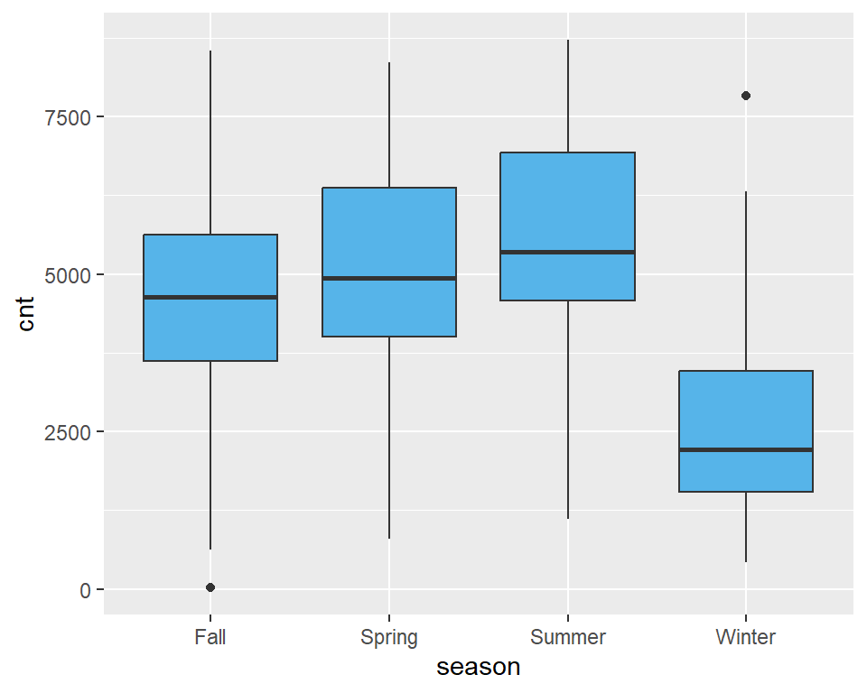

```r
qplot(data = bikes, x = season, y = cnt, fill = I(cbPalette[3]), geom = "boxplot")
```

There’s something funny going on here. Instead of showing up in seasonal order, the seasons in the plot are showing up in **alphabetical order**. The following command reorders the seasons appropriately.

```r
bikes <- mutate(bikes, season = factor(season, levels = c("Winter", "Spring", "Summer", "Fall")))
```

Now let’s try that plot again.

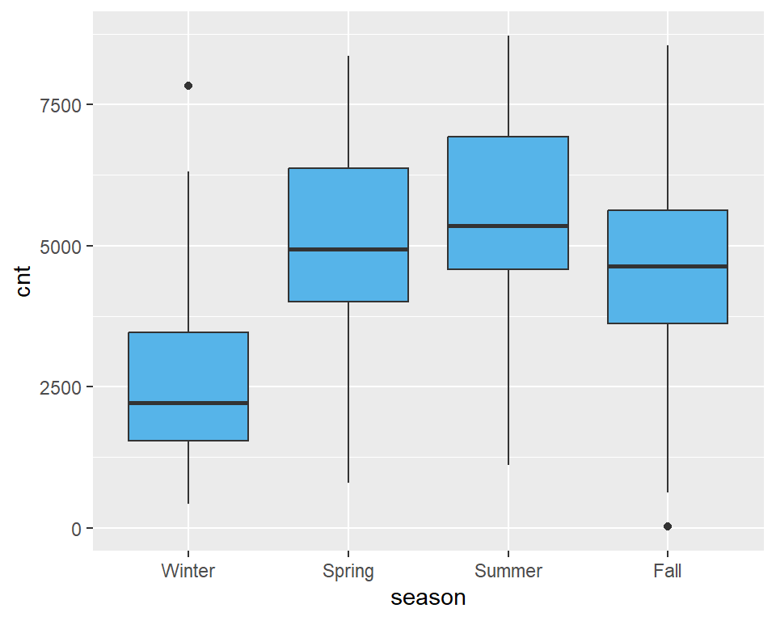

```r
qplot(data = bikes, x = season, y = cnt, fill = I(cbPalette[3]), geom = "boxplot")
```

Here’s information on what the variables mean.

- instant: record index
  - dteday : date
  - season : season (1:Winter, 2:Spring, 3:Summer, 4:Fall)
  - yr : year (0: 2011, 1:2012)
  - mnth : month ( 1 to 12)
  - hr : hour (0 to 23)
  - holiday : whether day is holiday or not (extracted from http://dchr.dc.gov/page/holiday-schedule)
  - weekday : day of the week
  - workingday : if day is neither weekend nor holiday is 1, otherwise is 0.
  - weathersit :
    - 1: Clear, Few clouds, Partly cloudy, Partly cloudy
    - 2: Mist + Cloudy, Mist + Broken clouds, Mist + Few clouds, Mist
    - 3: Light Snow, Light Rain + Thunderstorm + Scattered clouds, Light Rain + Scattered clouds
    - 4: Heavy Rain + Ice Pallets + Thunderstorm + Mist, Snow + Fog
  - temp : Temperature in Celsius.
  - atemp: `feels like’ temperature in Celsius.
  - hum: Normalized humidity. The values are divided to 100 (max)
  - windspeed: Normalized wind speed. The values are divided to 67 (max)
  - casual: count of casual users
  - registered: count of registered users
  - cnt: count of total rental bikes including both casual and registered

### Problem 1: Qualitative predictors

> The Season variable is an example of what’s called a *qualitative* or *categorical* predictor. In R, such variables are called `factors`. This problems gets to fit a model with a qualitative predictor and to interpret the findings.

##### **(a)** Suppose we were interested in predicting the count of total bike rentals by using the *season* as the predictor. Fit a linear (using the lm command) regression model with `cnt` as the response and `season` as the input. Use the `tidy()` and `kable()` commands to produce a nice looking coefficients table.

(Maybe look at https://rstudio-pubs-static.s3.amazonaws.com/58870_136d938b1ffd427ab5b30a98b663b127.html for an idea)

```r
szn_lm = lm(cnt ~ season, bikes)
tidy(szn_lm)
```

```
## # A tibble: 4 × 5
##   term         estimate std.error statistic  p.value
##   <chr>           <dbl>     <dbl>     <dbl>    <dbl>
## 1 (Intercept)     2604.      117.      22.3 1.55e-84
## 2 seasonSpring    2388.      164.      14.5 3.04e-42
## 3 seasonSummer    3040.      163.      18.6 1.60e-63
## 4 seasonFall      2124.      166.      12.8 4.24e-34
```

##### **(d)** Interpret the coefficients of `season` in the model.

- The model treats the winter season as the intercept, as it is both the first level of the qualitative variable and the level with the lowest average bikeshare count. With this in mind, the estimates for other seasons are all relative to the intercept (winter season). Essentially, the model estimates that if it is winter, bikeshare will be ~2604. Meanwhile, if it is Spring, Summer, or Fall bikeshare count will INCREASE FROM THE WINTER BASELINE by ~2388, ~3040, or ~2124, respectively. Overall, the model describes the estimated outcome (change in count) from a change from Winter to the discussed season. The model also provides several values representing the confidence of this estimate.

**Hint**: If you have not previously studied how to interpret qualitative variables in regressions, perhaps search on key terms ‘lm’, ‘r’, ‘categorical predictor’ ‘interpreting’.

### Problem 2: Multiple linear regression

> In this problem we’ll practice fitting and interpreting the results of a multiple linear regression.

##### **(a)** Fit a regression model with `cnt` as the response and the following variables as inputs: `temp`, `atemp`, `mnth`, `hum`, `windspeed`. Produce a nice looking coefficients table.

```r
lm_full = lm(cnt ~ temp + atemp + mnth + hum + windspeed, data = bikes)
tidy(lm_full)
```

```
## # A tibble: 6 × 5
##   term        estimate std.error statistic  p.value
##   <chr>          <dbl>     <dbl>     <dbl>    <dbl>
## 1 (Intercept)   5058.     343.      14.8   2.60e-43
## 2 temp            45.4     47.4      0.957 3.39e- 1
## 3 atemp           72.0     38.1      1.89  5.94e- 2
## 4 mnth            95.0     15.7      6.04  2.50e- 9
## 5 hum            -35.3      3.80    -9.28  1.98e-19
## 6 windspeed      -59.2     10.6     -5.58  3.39e- 8
```

##### **(b)** Interpret the coefficients of `temp`, `mnth` and `hum` in the model.

- These coefficients (estimate column in above table) represent the estimated change in bikeshare count (“cnt”) resulting from a change in that variable by 1 unit. For instance, an increase in temperature by 1 degree celcius is estimated to cause an increase in bikeshare count from the baseline (intercept estimate) by ~45. Meanwhile, a 1% increase in humidity is estimated to result in a decrease in bikeshare count from the baseline estimate by ~35. The model estimates that as month increases, bikeshare count increases (~95 per increase in month by 1). This is not intuitive and obviously not causal, because increasing month from January to December in no way causes increased bikeshare count (in fact, winter usage is minimal, including December). Nonetheless, the model provides this positive estimate because, as a trend overall, bikeshare increases as the distance from January increases.

##### **(c)** Which predictors are associated with increased ridership? Which predictors are associated with decreased ridership?

- Increased ridership (bikeshare count) is associated with increasing temperature, ‘feels-like’ temperature, and month. Meanwhile, decreased ridership is associated with increasing humidity and wind speed.

### Problem 3: Dealing with collinearity

> As you probably already know from your most recent regression class, *collinear* or *highly correlated* predictors can make interpreting regression coefficients problematic. In this problem you will try to diagnose and address collinearity issues in the data.

##### **(a)** Use the `pairs()` function on the set of variables used in **Problem 2** to check if any of the predictor variables are highly correlated with one another. Your pairs plot should have scatterplots above the diagonal, and correlations below the diagonal.

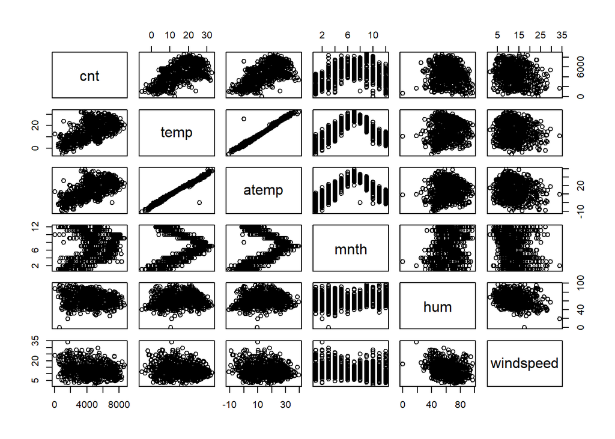

```r
pairs(data = bikes, cnt ~ temp + atemp + mnth + hum + windspeed)
```

**Hint**: A complete example of how to use the `pairs()` command to construct such plots may be found here: [Pairs plot example](http://www.andrew.cmu.edu/user/achoulde/94842/lectures/lecture08/lecture08-94842.html#collinearity-and-pairs-plots)

##### **(b)** Are any of the predictors highly correlated? Are you surprised that these predictors are highly correlated, or can you think of a reason for why it makes sense that they should be correlated?

- ‘temp’ and ‘atemp’ are highly correlated. This is unsurprising, because one would assume that the temperature it feels like would increase in direct response to an increase in actual temperature. This is an unnecessary collinearity that can easily be removed by selecting either one or the other of these variables. While less obvious, it appears that ‘mnth’ is also correlated with both temperature metrics, and somewhat with all weather metrics. Month is not a very valuable predictive variable, in this case, because it provides minimal causal influence upon bikeshare count intuitively (one would think). Therefore, a more efficient and simplified model might opt to use just ‘temp’, ‘hum’, and ‘windspeed’ as variables in the regression to truly understand how weather conditions affect ridership. From these results, information relating ridership and month could be extrapolated.

##### **(c)** Refit your regression model, but this time **omit** the `temp` variable. Display the coefficients table for this model.

```r
lm_tempomit = lm(cnt ~ atemp + mnth + hum + windspeed, data = bikes)
tidy(lm_tempomit)
```

```
## # A tibble: 5 × 5
##   term        estimate std.error statistic  p.value
##   <chr>          <dbl>     <dbl>     <dbl>    <dbl>
## 1 (Intercept)   5187.     315.       16.5  5.56e-52
## 2 atemp          108.       4.97     21.8  2.74e-81
## 3 mnth            95.0     15.7       6.04 2.51e- 9
## 4 hum            -35.4      3.80     -9.34 1.18e-19
## 5 windspeed      -57.4     10.4      -5.50 5.33e- 8
```

##### **(d)** What is the coefficient of `atemp` in this new model? Is it very different from the `atemp` coefficient estimated in part **(b)**? Is it statistically significant? Explain your findings.

- The new coefficient of ‘atemp’ is ~108, where it was previously ~72. This is a drastic difference, indicating that the previously observed collinearity was indeed problematic. Its statistical significant also increased drastically from ~1.8 to ~21. Therefore, eliminating the collinear variable ‘temp’ showed that ‘atemp’ is truly highly predictive of ridership - even more so than any other variable observed in the above model.

Additional plots for explorative analysis:

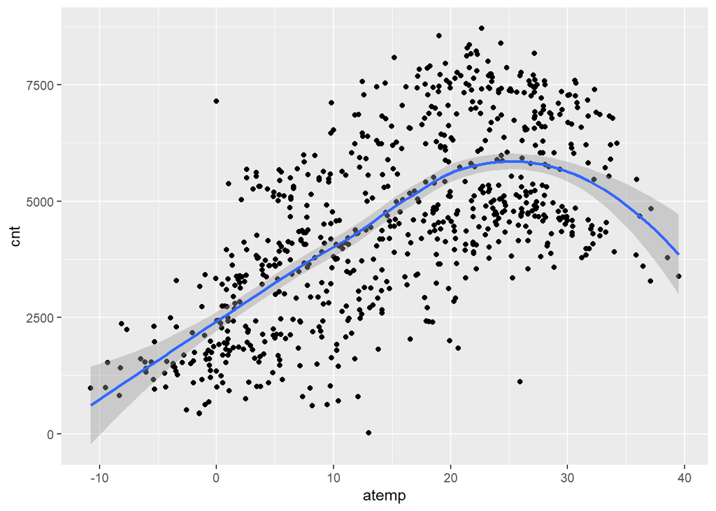

```r
fig1_temp = bikes |> ggplot(aes(x = atemp, y = cnt)) +
            geom_point() + geom_smooth()
fig1_temp
```

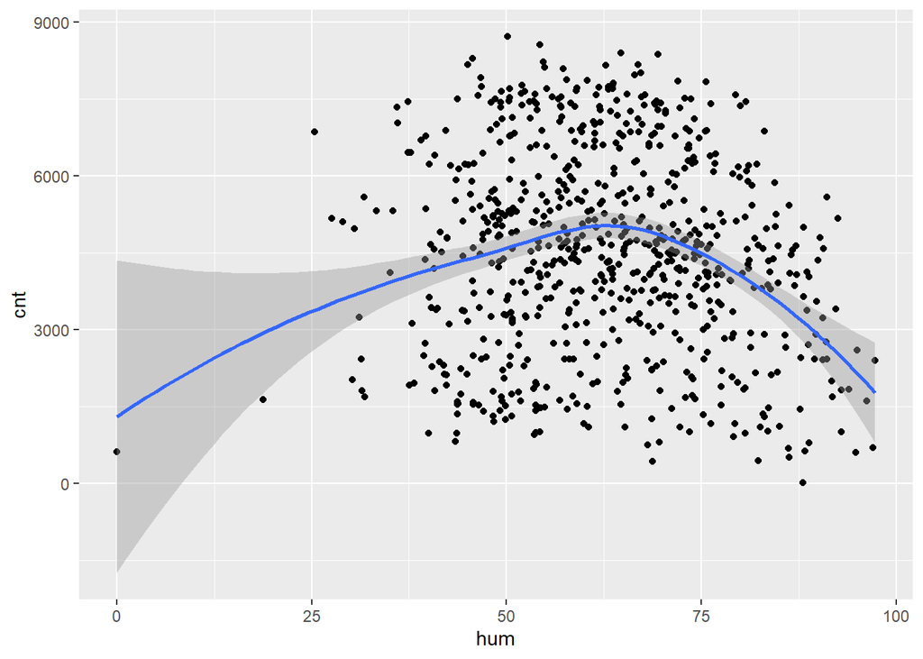

```r
fig2_hum = bikes |> ggplot(aes(x = hum, y = cnt)) +
            geom_point() + geom_smooth()
fig2_hum
```

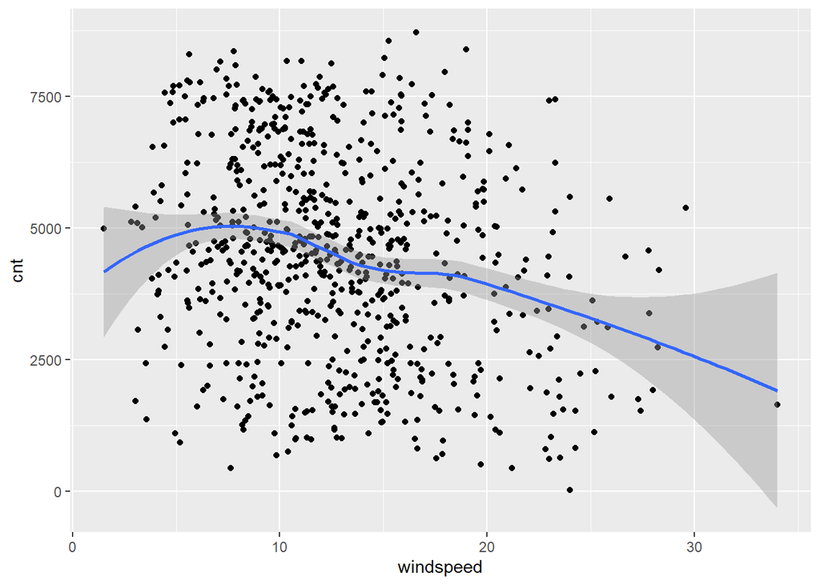

```r
fig3_wind = bikes |> ggplot(aes(x = windspeed, y = cnt)) +
            geom_point() + geom_smooth()
fig3_wind
```